# Capsule 3 - Ajouter une transformation simple

MQT-2101 - Analyse et modélisation des données

## Pourquoi ça compte

Comment représenter une hausse qui ralentit?

Une droite, une courbe quadratique et un logarithme imposent des formes différentes. Le choix doit rester lisible sur l’échelle des ventes.

## Objectifs de la capsule

- Écrire trois modèles candidats.
- Ajuster les modèles avec lm().
- Interpréter une différence de prédictions.

## Trois formes, une même réponse

On note $x$ l’achalandage en milliers de visites et $y$ les ventes en dollars.

| Forme | Moyenne modélisée |
| --- | --- |
| Droite | $\beta_0+\beta_1x$ |
| Quadratique | $\beta_0+\beta_1x+\beta_2x^2$ |
| Logarithmique | $\beta_0+\beta_1\ln(x)$, avec $x>0$ |

## Courbe en x, modèle linéaire en paramètres

$$Y=\beta_0+\beta_1x+\beta_2x^2+\varepsilon$$

Le modèle reste linéaire en ses coefficients : `lm()` convient. Une relation courbée n’exige pas forcément une régression non linéaire en paramètres.

## Fixer les données d’apprentissage

```r
saturation <- saturation |>
  mutate(achalandage_milliers = achalandage / 1000)
apprentissage <- saturation |>
  filter(mois < as.Date("2025-10-01"))
validation <- saturation |>
  filter(mois >= as.Date("2025-10-01"))
```

## Ajuster la droite et la quadratique

```r
modele_lin <- lm(ventes ~ achalandage_milliers,
                 data = apprentissage)
modele_quad <- lm(
  ventes ~ achalandage_milliers + I(achalandage_milliers^2),
  data = apprentissage
)
```

`I(x^2)` demande le carré numérique. Conservez aussi le terme x.

## Interpréter une variation

| Comparaison | Hausse prédite (dollars) |
| --- | --- |
| 2 000 à 2 100 visites | 3 487 |
| 3 000 à 3 100 visites | 1 763 |

Pour 100 visites supplémentaires, la hausse prédite dépend du point de départ.

## Calculer une différence dans la quadratique

$$\widehat y(x+h)-\widehat y(x)=b_1h+b_2(2xh+h^2)$$

- x et x² changent ensemble.
- 100 visites : h = 0,1 millier.
- Le point de départ x intervient.

## Transformer l’explicative avec un logarithme

```r
modele_log <- lm(ventes ~ log(achalandage_milliers),
                 data = apprentissage)
```

Pour une hausse de 10 % de x : $\Delta\widehat{y}=b_1\ln(1{,}10)$.

La réponse reste en dollars. Il n’y a pas de transformation inverse de y à effectuer.

## Superposer les trois formes

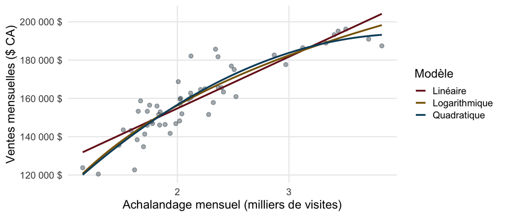

## Ce que la forme ne garantit pas

- Quadratique : une courbure, sans plateau imposé.
- Logarithme : défini seulement pour x positif.
- Une meilleure apparence doit être confrontée à la validation.

## À retenir

Forme

trois candidats explicites

Échelle

ventes en dollars

Variation

comparer des prédictions

## Production autonome 4.3

Ajustez les trois modèles sur janvier à septembre. Avec le modèle quadratique, comparez la hausse prédite de 2 000 à 2 100 visites à celle de 3 000 à 3 100 visites.

### Auto-vérification

- J’ai exprimé x en milliers de visites.
- Les trois modèles utilisent les mêmes 54 lignes.
- Je n’interprète pas le coefficient de x comme une pente constante dans le modèle quadratique.